# Lab 4 — School Data: Summaries, “Top” Schools & Regression

Quantitative Reasoning · LAB 413

Instructor: Subin Na

September 24, 2025

> **How to use this document.** Run the code along with me. Comments start with `#`. If you see errors, read them! They usually tell you the fix.

**Today’s plan**

1. Fresh start + packages
2. Import & understand the School data
3. Count unique schools
4. Summaries: zero-suspension and attendance rates
5. “Top” schools: highest suspension, graduation, most graduates, most students
6. Correlations
7. Regression refresher (`lm`) + residuals
8. Quick practice

# 1 Fresh Start + Packages

```r
rm(list = ls())   # (optional) clean environment

# Load (every session)
library(tidyverse)  # data tools (ggplot2, dplyr, readr, etc.)
library(dplyr)      # data wrangling (filter, select, summarize, mutate)
library(ggplot2)    # plotting (geom_*)
```

> In the live session we set the working directory with `setwd(...)`. In this document the data file `SchoolData.csv` sits next to the `.Rmd`, so no `setwd()` is needed.

# 2 Import & Understand the School Data

```r
schooldata <- read.csv("SchoolData.csv")

# Quick peek
dim(schooldata)      # rows, columns
```

```
#> [1] 213  23
```

```r
names(schooldata)    # variable names
```

```
#>  [1] "year_academic" "id_school"     "name_school"   "sector"
#>  [5] "category"      "group"         "oss_denom"     "oss_0_numer"
#>  [9] "oss_0_pct"     "oss_1_numer"   "oss_1_pct"     "oss_2_numer"
#> [13] "oss_2_pct"     "oss_3_numer"   "oss_3_pct"     "oss_4_numer"
#> [17] "oss_4_pct"     "att_denom"     "att_95_numer"  "att_95_pct"
#> [21] "grad_denom"    "grad_4_numer"  "grad_4_pct"
```

```r
# In RStudio you would run View(schooldata); here we preview the first rows.
knitr::kable(head(schooldata, 10), caption = "First rows of the School data")
```

First rows of the School data

| year_academic | id_school | name_school | sector | category | group | oss_denom | oss_0_numer | oss_0_pct | oss_1_numer | oss_1_pct | oss_2_numer | oss_2_pct | oss_3_numer | oss_3_pct | oss_4_numer | oss_4_pct | att_denom | att_95_numer | att_95_pct | grad_denom | grad_4_numer | grad_4_pct |
| --- | --- | --- | --- | --- | --- | --- | --- | --- | --- | --- | --- | --- | --- | --- | --- | --- | --- | --- | --- | --- | --- | --- |
| 2018-2019 | 1010 | John Bartram High School | District | All Students | All Students | 683 | 579 | 84.77 | 84 | 12.30 | 14 | 2.05 | 6 | 0.88 | 0 | 0.00 | 683 | 174 | 25.48 | 159 | 94 | 59.12 |
| 2018-2019 | 1020 | West Philadelphia High School | District | All Students | All Students | 501 | 421 | 84.03 | 61 | 12.18 | 12 | 2.40 | 4 | 0.80 | 3 | 0.60 | 501 | 68 | 13.57 | 114 | 70 | 61.40 |
| 2018-2019 | 1030 | High School of the Future | District | All Students | All Students | 561 | 507 | 90.37 | 40 | 7.13 | 12 | 2.14 | 1 | 0.18 | 1 | 0.18 | 561 | 251 | 44.74 | 107 | 88 | 82.24 |
| 2018-2019 | 1050 | Paul Robeson High School for Human Services | District | All Students | All Students | 323 | 308 | 95.36 | 14 | 4.33 | 1 | 0.31 | 0 | 0.00 | 0 | 0.00 | 323 | 122 | 37.77 | 76 | 71 | 93.42 |
| 2018-2019 | 1100 | William L. Sayre High School | District | All Students | All Students | 539 | 418 | 77.55 | 83 | 15.40 | 30 | 5.57 | 6 | 1.11 | 2 | 0.37 | 539 | 84 | 15.58 | 103 | 55 | 53.40 |
| 2018-2019 | 1130 | William T. Tilden School | District | All Students | All Students | 457 | 362 | 79.21 | 59 | 12.91 | 16 | 3.50 | 9 | 1.97 | 11 | 2.41 | 457 | 233 | 50.98 | NA | NA | NA |
| 2018-2019 | 1190 | Motivation High School | District | All Students | All Students | 417 | 383 | 91.85 | 31 | 7.43 | 3 | 0.72 | 0 | 0.00 | 0 | 0.00 | 417 | 327 | 78.42 | 88 | 75 | 85.23 |
| 2018-2019 | 1200 | John Barry School | District | All Students | All Students | 764 | 722 | 94.50 | 35 | 4.58 | 5 | 0.65 | 2 | 0.26 | 0 | 0.00 | 764 | 211 | 27.62 | NA | NA | NA |
| 2018-2019 | 1230 | William C. Bryant School | District | All Students | All Students | 525 | 483 | 92.00 | 29 | 5.52 | 13 | 2.48 | 0 | 0.00 | 0 | 0.00 | 525 | 119 | 22.67 | NA | NA | NA |
| 2018-2019 | 1250 | Joseph W. Catharine School | District | All Students | All Students | 536 | 534 | 99.63 | 1 | 0.19 | 1 | 0.19 | 0 | 0.00 | 0 | 0.00 | 536 | 246 | 45.90 | NA | NA | NA |

**Extended codebook** (suspensions, attendance, graduation)

OSS = Out-of-School Suspension (a student kept out of school for up to 10 days).

- **Suspension denominator (population base)**
  - `oss_denom` = total number of students in the school (denominator for suspension %).
- **Counts (numerators) by suspension frequency**
  - `oss_0_numer` … `oss_4_numer` = # of students with exactly 0, 1, 2, 3, or 4+ OSS.
- **Percentages by suspension frequency** (relative to `oss_denom`)
  - `oss_0_pct` … `oss_4_pct` = % of students with exactly 0, 1, 2, 3, or 4+ OSS (`oss_4_pct` is the “highest suspension rate”).
- **Attendance ($\geq$ 95% of days)**
  - `att_denom`, `att_95_numer`, `att_95_pct`.
- **Graduation (4-year on-time)**
  - `grad_denom`, `grad_4_numer`, `grad_4_pct`.
- **IDs and labels**
  - `year_academic`, `id_school`, `name_school`.

> Notes: `_numer` columns are counts; `_pct` columns are percentages (0–100), typically computed as `100 * (numerator / denominator)`. Each row is usually a school-year record.

# 3 Count Unique Schools

```r
nrow(schooldata)                      # if each row = a school
```

```
#> [1] 213
```

```r
n_distinct(schooldata$id_school)      # safer - counts unique IDs
```

```
#> [1] 213
```

```r
n_distinct(schooldata$name_school)
```

```
#> [1] 213
```

# 4 Summaries: Zero Suspensions & Attendance

**Average % of students with ZERO suspensions.** `summarize()` collapses the dataset into a tiny summary table.

```r
schooldata %>%
  summarize(avg_zero_suspensions = mean(oss_0_pct, na.rm = TRUE),
            median_zero_sus      = median(oss_0_pct, na.rm = TRUE),
            max                  = max(oss_0_pct, na.rm = TRUE))
```

| avg_zero_suspensions | median_zero_sus | max |
| --- | --- | --- |
| 93.63122 | 95.43 | 100 |

**Average attendance % (`att_95_pct`).**

```r
schooldata %>%
  summarize(avg_attendance_rate = mean(att_95_pct, na.rm = TRUE))
```

| avg_attendance_rate |
| --- |
| 45.66742 |

# 5 “Top” Schools

**School with the HIGHEST suspension rate.** Start with the data, then `filter`, then `select`.

```r
school_highest_suspension <-
  schooldata %>%
  filter(oss_4_pct == max(oss_4_pct, na.rm = TRUE)) %>%
  select(name_school, oss_4_pct)

school_highest_suspension
```

| name_school | oss_4_pct |
| --- | --- |
| Robert E. Lamberton School | 4.79 |

**School with the HIGHEST graduation rate.**

```r
school_highest_graduation <-
  schooldata %>%
  filter(grad_4_pct == max(grad_4_pct, na.rm = TRUE)) %>%
  select(name_school, grad_4_pct)

school_highest_graduation
```

| name_school | grad_4_pct |
| --- | --- |
| Julia R. Masterman School | 100 |
| Girard Academic Music Program | 100 |

**Schools with “perfect attendance.”**

```r
perfect_attendance <-
  schooldata %>%
  filter(att_95_pct == 100) %>%  # how I first define "perfect"
  select(name_school, att_95_pct)

perfect_attendance
```

| name_school | att_95_pct |
| --- | --- |

> **Practice — redefine “perfect attendance.”** Start with `att_95_pct >= 95`, and lower the threshold (90, 85, 80, …) until schools appear.

```r
perfect_attendance <-
  schooldata %>%
  filter(att_95_pct >= 85) %>%
  select(name_school, att_95_pct)

perfect_attendance
```

| name_school | att_95_pct |
| --- | --- |
| Julia R. Masterman School | 89.13 |
| Central High School | 85.57 |

**School with the MOST graduates.**

```r
school_most_graduates <-
  schooldata %>%
  filter(grad_4_numer == max(grad_4_numer, na.rm = TRUE)) %>%
  select(name_school, grad_4_numer)

school_most_graduates
```

| name_school | grad_4_numer |
| --- | --- |
| Northeast High School | 586 |

**School with the MOST students.**

```r
school_most_students <-
  schooldata %>%
  filter(oss_denom == max(oss_denom, na.rm = TRUE)) %>%
  select(name_school, oss_denom)

school_most_students
```

| name_school | oss_denom |
| --- | --- |
| Northeast High School | 3698 |

# 6 Correlations

Correlation between the total number of students and the number of students who graduated in four years.

```r
schooldata %>%
  summarize(total_vs_grad_num =
              cor(oss_denom, grad_4_numer, use = "complete.obs"))
```

| total_vs_grad_num |
| --- |
| 0.9156671 |

> **Practice.** Correlation between attendance percentage and graduation percentage — what does it tell you about their relationship?

```r
schooldata %>%
  summarize(att_vs_grad =
              cor(att_95_pct, grad_4_pct, use = "complete.obs"))
```

| att_vs_grad |
| --- |
| 0.7628477 |

# 7 Regression Refresher (`lm`)

Fit a regression: attendance % as a function of zero-suspension %.

```r
m1 <- lm(att_95_pct ~ oss_0_pct, data = schooldata)
summary(m1)
```

```
#>
#> Call:
#> lm(formula = att_95_pct ~ oss_0_pct, data = schooldata)
#>
#> Residuals:
#>     Min      1Q  Median      3Q     Max
#> -27.171 -10.417  -1.643   7.405  35.349
#>
#> Coefficients:
#>             Estimate Std. Error t value Pr(>|t|)
#> (Intercept) -90.7972    14.2159  -6.387 1.06e-09 ***
#> oss_0_pct     1.4575     0.1515   9.622  < 2e-16 ***
#> ---
#> Signif. codes:  0 '***' 0.001 '**' 0.01 '*' 0.05 '.' 0.1 ' ' 1
#>
#> Residual standard error: 14.09 on 211 degrees of freedom
#> Multiple R-squared:  0.305,  Adjusted R-squared:  0.3017
#> F-statistic: 92.58 on 1 and 211 DF,  p-value: < 2.2e-16
```

Scatterplot with a loess curve (red) and a regression line (blue).

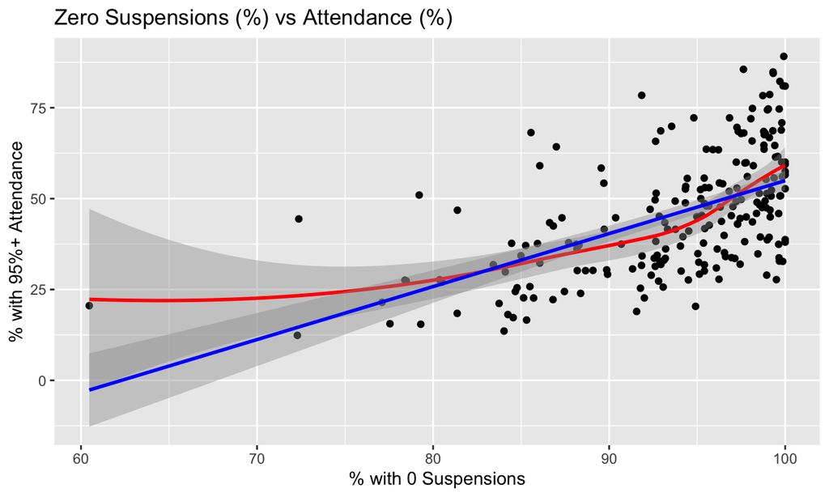

```r
ggplot(schooldata, aes(x = oss_0_pct, y = att_95_pct)) +
  geom_point() +
  geom_smooth(color = "red") +                  # loess curve
  geom_smooth(method = lm, color = "blue") +    # regression line
  labs(title = "Zero Suspensions (%) vs Attendance (%)",
       x = "% with 0 Suspensions",
       y = "% with 95%+ Attendance")
```

# 8 Residuals

Create a new column of residuals, then plot them. A good residual plot is centered around 0 with no pattern.

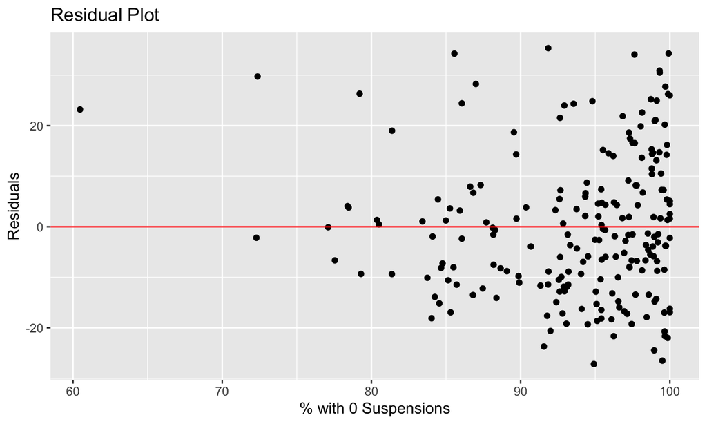

```r
schooldata <- schooldata %>%
  mutate(Residuals = residuals(m1)) # residuals for the model

ggplot(schooldata, aes(x = oss_0_pct, y = Residuals)) +
  geom_point() +                               # residual vs predictor
  geom_hline(yintercept = 0, color = "red") +  # perfect-prediction line
  labs(title = "Residual Plot",
       x = "% with 0 Suspensions",
       y = "Residuals")
```

# 9 Quick Practice

**P1) On average, what percentage of students had exactly 1 suspension across all schools?**

```r
# base R way
mean(schooldata$oss_1_pct)
```

```
#> [1] 4.327606
```

```r
# tidyverse
schooldata %>%
  summarize(avg_oss1_pct = mean(oss_1_pct, na.rm = TRUE))
```

| avg_oss1_pct |
| --- |
| 4.327606 |

**P2) Which school had the largest number of students with exactly 2 suspensions?**

```r
schooldata %>%
  filter(oss_2_numer == max(oss_2_numer, na.rm = TRUE)) %>%
  select(name_school, oss_2_numer, year_academic)
```

| name_school | oss_2_numer | year_academic |
| --- | --- | --- |
| Northeast High School | 68 | 2018-2019 |

**P3) Is there a correlation between attendance rate and the total number of students in the school?**

```r
cor(schooldata$att_95_pct, schooldata$oss_denom, use = "complete.obs")
```

```
#> [1] 0.1182958
```

**P4) Fit a regression predicting attendance % from total number of students. What is the slope?**

```r
m2 <- lm(att_95_pct ~ oss_denom, data = schooldata)
summary(m2)
```

```
#>
#> Call:
#> lm(formula = att_95_pct ~ oss_denom, data = schooldata)
#>
#> Residuals:
#>     Min      1Q  Median      3Q     Max
#> -33.252 -13.552  -0.786  11.294  40.604
#>
#> Coefficients:
#>              Estimate Std. Error t value Pr(>|t|)
#> (Intercept) 42.339385   2.240539   18.90   <2e-16 ***
#> oss_denom    0.005096   0.002945    1.73    0.085 .
#> ---
#> Signif. codes:  0 '***' 0.001 '**' 0.01 '*' 0.05 '.' 0.1 ' ' 1
#>
#> Residual standard error: 16.78 on 211 degrees of freedom
#> Multiple R-squared:  0.01399,    Adjusted R-squared:  0.009321
#> F-statistic: 2.995 on 1 and 211 DF,  p-value: 0.085
```

**P5) Add residuals from the P4 model and make a residual plot.**

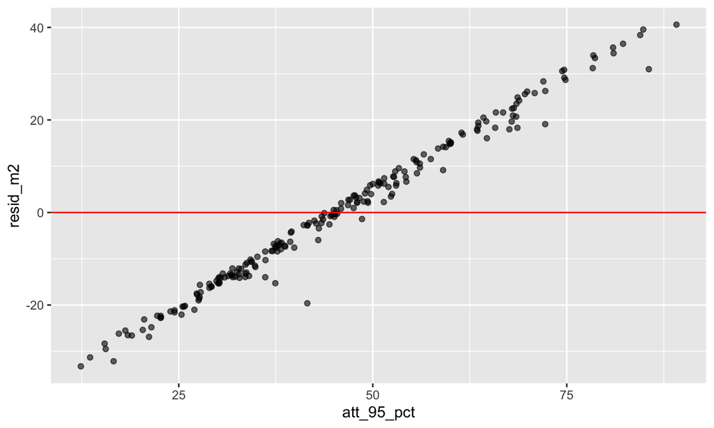

```r
schooldata$resid_m2 <- residuals(m2)

ggplot(schooldata, aes(x = att_95_pct, y = resid_m2)) +
  geom_point(alpha = 0.6) +
  geom_hline(yintercept = 0, color = "red")
```

> *Interpretation.* The residuals form a strong diagonal line — almost like another regression line. This means the model is not capturing the relationship correctly and suggests model assumptions (linearity or independence) are violated.

**P6) Make a histogram of residuals.**

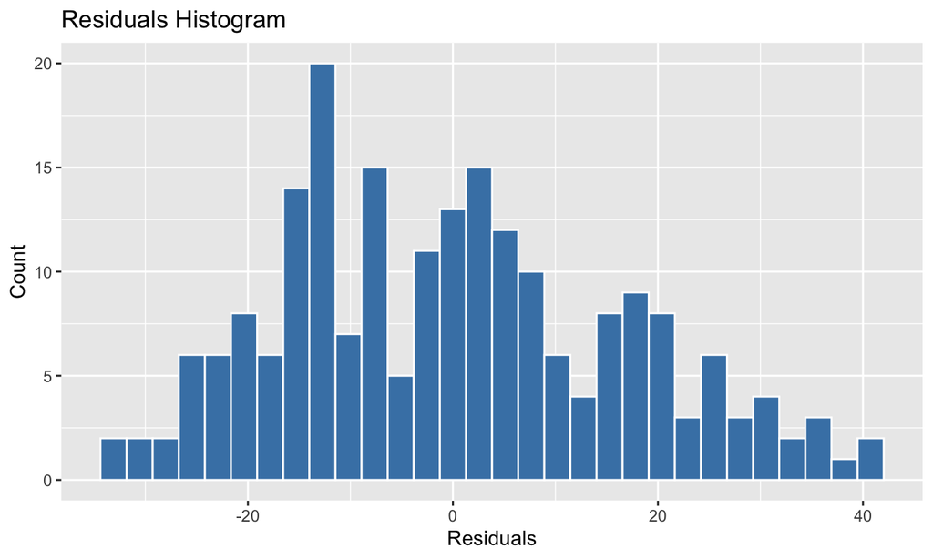

```r
ggplot(schooldata, aes(x = resid_m2)) +
  geom_histogram(bins = 30, color = "white", fill = "steelblue") +
  labs(title = "Residuals Histogram", x = "Residuals", y = "Count")
```